# Module 4

STAT 6021

Taylor R. Brown, PhD

# Multiple Linear Regression

Everything we’ve done so far rested on these assumptions:

- linear relationship between $y$ and $x$ (i.e. $y =\mathbf{x}^{\intercal}\boldsymbol{\beta} + \epsilon$)
- $\epsilon_1, \ldots, \epsilon_n \overset{iid}{\sim} \text{Normal}(0, \sigma^2)$

# Residuals!

The residuals are our friend:

$$\mathbf{e} = \mathbf{y} - \hat{\mathbf{y}} = [\mathbf{I}- \mathbf{H} ]\mathbf{y}$$

# Residuals v1.0

Sometimes we look at the *standardized residuals* $d_i$

$$d_i = \frac{e_i}{\sqrt{MS_{Res}}}$$

Idea: make $V[d_i] \approx 1$

Why?
$$V[e_i] \approx \sigma^2 \approx MS_{Res}$$

# Residuals v2.0

We can do better:

mean
$$E[\mathbf{e}] = [\mathbf{I}- \mathbf{H} ]E[\mathbf{y} ]= [\mathbf{I}- \mathbf{H} ]\mathbf{X}\boldsymbol{\beta} = \mathbf{0}$$

covariance matrix
$$V[\mathbf{e}] = V[(\mathbf{I} - \mathbf{H})\mathbf{y}] = \sigma^2 (\mathbf{I} - \mathbf{H})(\mathbf{I} - \mathbf{H})^{\intercal} = \sigma^2 (\mathbf{I} - \mathbf{H})$$

- $V[e_i] = \sigma^2(1 - h_{ii})$
- $\text{Cov}( e_i, e_j) = -\sigma^2h_{i,j}$
- $V[\mathbf{e}]$ is not full rank!

# Residuals v2.0

Because
$$e_i \sim \text{Normal}\left(0, \sigma^2(1 - h_{ii}) \right)$$

it’s better to look at the *(internally) studentized residuals*
$$r_i = \frac{e_i}{\sqrt{ MS_{Res} (1 - h_{ii}) }} \overset{\text{approx.}}{\sim} t_{df_{Res}}$$

…still correlated, [not exactly $t$-distributed](https://stats.stackexchange.com/questions/396190/do-studentized-residuals-follow-t-distribution/410385#410385), not exactly unit variance

# Residuals v3.0

The *externally studentized residuals* follow a t-distribution *exactly* (if $\boldsymbol{\epsilon}$ is normal). These are what we will use to check diagnostics.

$$t_i = \frac{e_i}{\sqrt{ MS_{(i),Res} (1 - h_{ii}) }} \sim t_{df_{Res}-1}$$

$MS_{(i),Res}$ differs from $MS_{Res}$ because it is based on all of the data except for the $i$th data point. This is also why we lose an extra degree of freedom!

# using `R`

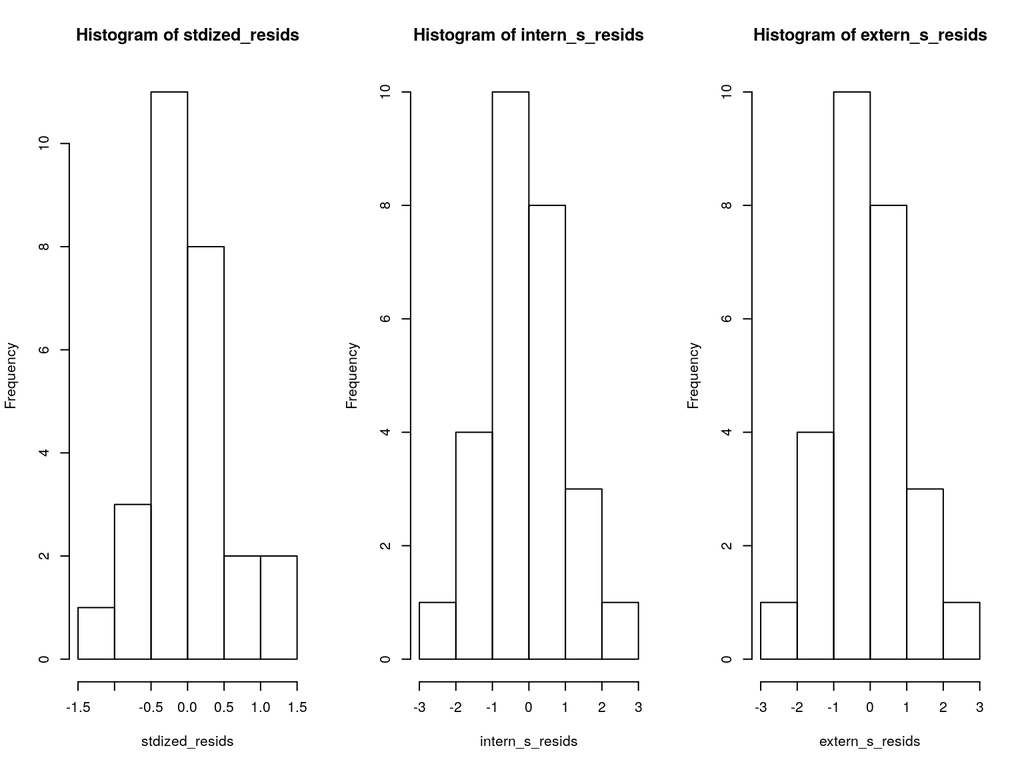

```r
# install.packages("MASS")
library(MASS)
mod <- lm(y ~ ., data = my_data)
stdized_resids <- residuals(mod)/sqrt(anova(mod)$'Mean Sq'[3])
intern_s_resids <- stdres(mod)
extern_s_resids <- studres(mod)
par(mfrow=c(1,3))
hist(stdized_resids)
hist(intern_s_resids)
hist(extern_s_resids)
```

```r
par(mfrow=c(1,1))
```

# using `R`

internally versus externally…

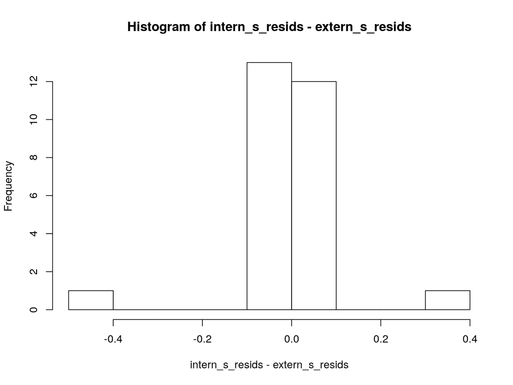

```r
# install.packages("MASS")
intern_s_resids <- stdres(mod)
extern_s_resids <- studres(mod)
hist(intern_s_resids - extern_s_resids)
```

# Plotting Residuals

- check for normality
- checking homoskedasticity
- checking linearity/missing predictors
- checking for outliers

Plots:

- $t_i$ by themselves
- $t_i$ versus $\hat{y}_i$
- $t_i$ versus $x_{ij}$ for any $j$ (in particular if one predictor is time)
- partial regression and partial residual plots

# Checking normality

If $\boldsymbol{\epsilon}$ is normal, then $\{t_i\}$ are iid $t_{df_{Res}-1}$

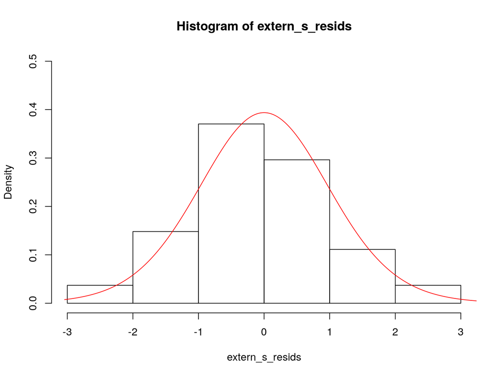

```r
x_grid <- seq(min(extern_s_resids)-.5, max(extern_s_resids)+.5, by = .01)
dfRes <- nrow(my_data) - 7 - 1 # 7 predictors and one intercept
hist(extern_s_resids, probability = T, ylim = c(0,.5))
t_densities <- dt(x_grid, dfRes)
points(x_grid, t_densities, type = "l", col = "red")
```

# Checking normality

QQ plots are a little better for spotting heavy/thin tails or skewness…

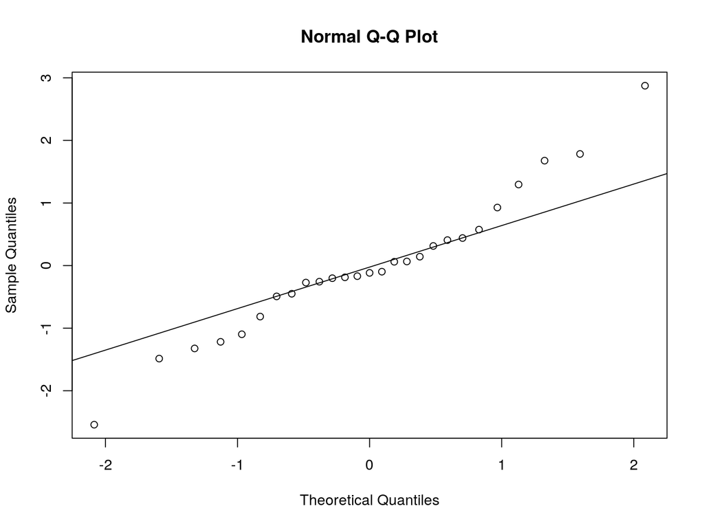

```r
qqnorm(extern_s_resids)
qqline(extern_s_resids)
```

# Checking Homoskedasticity and Linearity

Always plot $t_i$ versus $\hat{y}_i$ to check for heteroskedasticity and nonlinearities

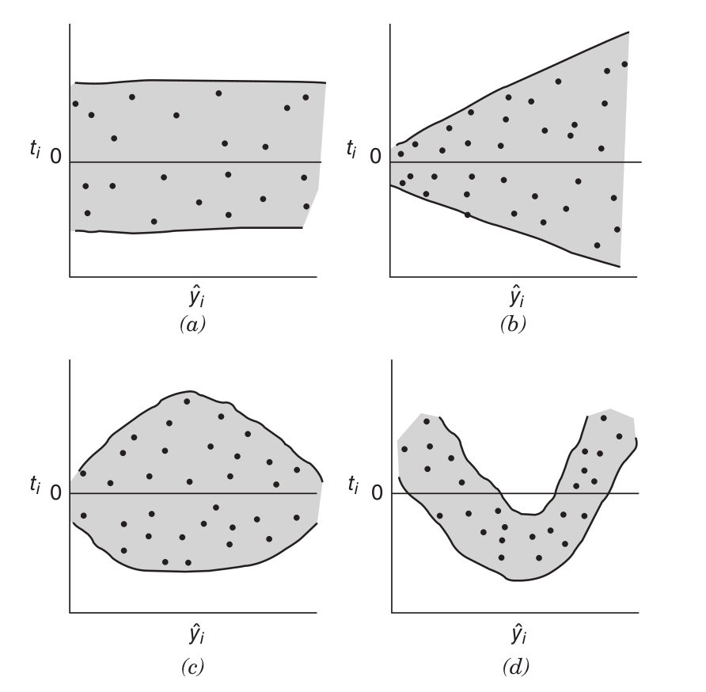

# Checking Homoskedasticity and Linearity

Our model’s plot:

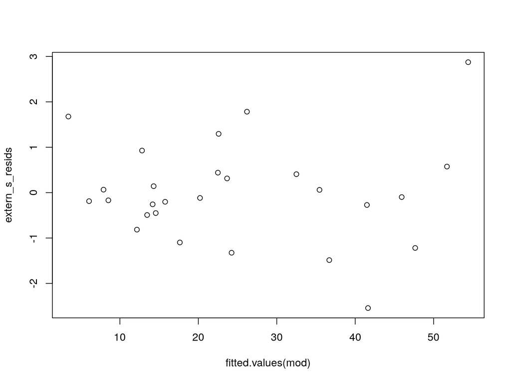

```r
plot(fitted.values(mod), extern_s_resids)
```

# Missing predictors?

Another example:

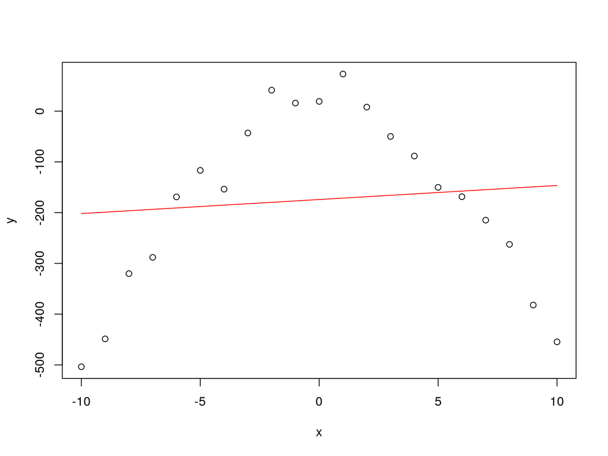

```r
bad_mod <- lm(y ~ x, data = my_df)
plot(my_df$x,my_df$y, xlab = "x", ylab = "y")
points(my_df$x, fitted.values(bad_mod), type ="l", col= "red")
```

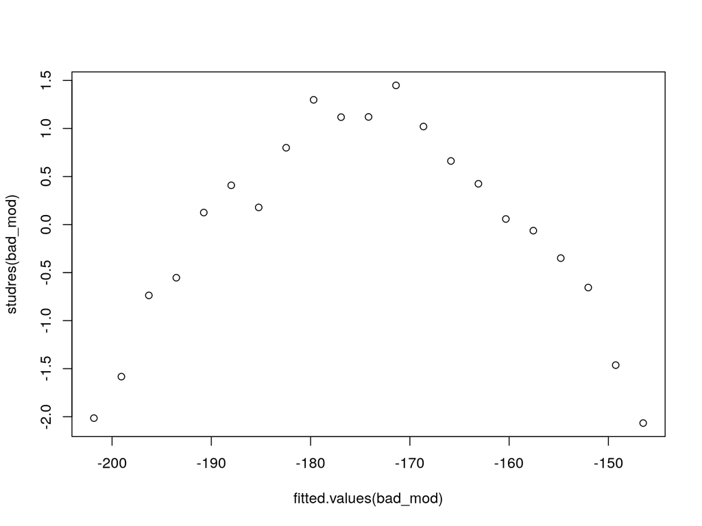

```r
plot(fitted.values(bad_mod), studres(bad_mod))
```

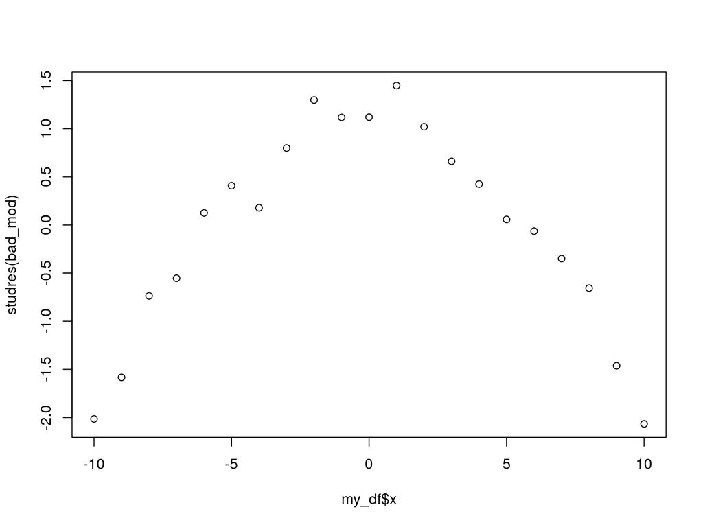

```r
plot(my_df$x, studres(bad_mod))
```

# Added-Variable Plots

A *partial regression plot* aka an *added-variable plot* plots two types of residuals against each other

- $\mathbf{y}$ against all predictors except $\mathbf{x}_i$
- $\mathbf{x}_i$ against all other predictors

The plot is straight-sloped if it should be included in the model. It’s horizontal if it’s redundant. And it’s curved if you might need to add a power of $\mathbf{x}_i$ to the regression model.

# Added-Variable Plots

```r
library(car)
head(my_data)
```

```
##       y   x1  x2    x3    x4      x5      x6   x7
## 1 36.98  5.1 400 51.37  4.24 1484.83 2227.25 2.06
## 2 13.74 26.4 400 72.33 30.87  289.94  434.90 1.33
## 3 10.08 23.8 400 71.44 33.01  320.79  481.19 0.97
## 4  8.53 46.4 400 79.15 44.61  164.76  247.14 0.62
## 5 36.42  7.0 450 80.47 33.84 1097.26 1645.89 0.22
## 6 26.59 12.6 450 89.90 41.26  605.06  907.59 0.76
```

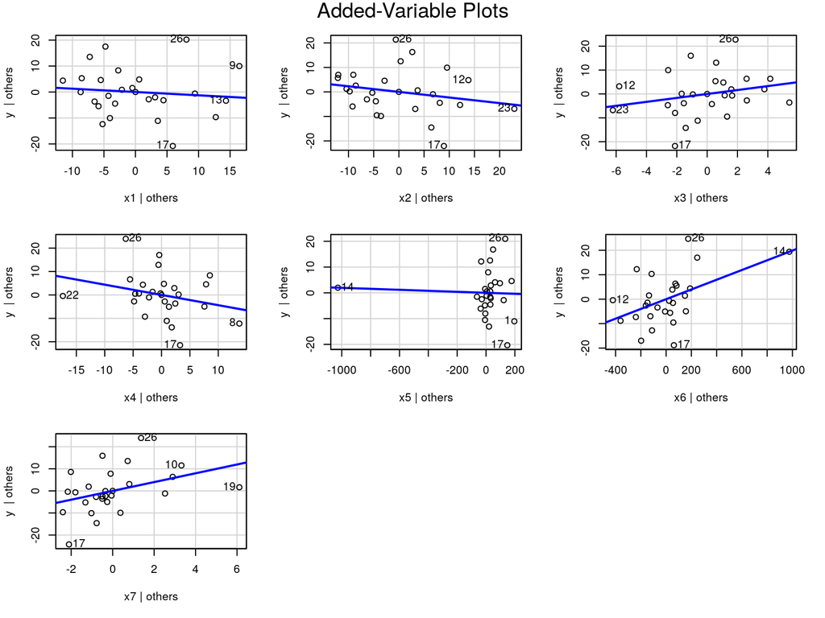

```r
avPlots(lm(y ~ ., data = my_data))
```

# Added-Variable Plots

Some intuition:

Say we are interested in looking at $x_1$. Pretend now that it *doesn’t* belong in the model.

- true model: $y = \beta_0 + \beta_2 x_2 + \epsilon$
- predictors are correlated: $x_1 = \alpha_0 + \alpha_1 x_2 + \tilde{\epsilon}$

The residuals from regressing $y$ on everything except for $x_1$ will roughly be $\epsilon$. These are uncorrelated with everything, and in particular, with the residuals of $x_1$ regressed on the others.

# Added-Variable Plots

Some intuition:

Say we are interested in looking at $x_1$. Pretend that it *does* belong in the model.

- true model: $y = \beta_0 + \beta_1 x_1 + \beta_2 x_2 + \epsilon$
- predictors are correlated: $x_1 = \alpha_0 + \alpha_1 x_2 + \tilde{\epsilon}$

Regressing $y$ on everything except for $x_1$ roughly gives you
$$y = \underbrace{\beta_0 + \beta_1 \alpha_0}_{\text{intercept}} + \underbrace{(\beta_2 + \beta_1 \alpha_1)}_{\text{slope}}x_2 + \underbrace{\epsilon + \beta_1 \tilde{\epsilon}}_{\text{residuals}}$$
So the residuals from regressing $y$ on everything else ($\epsilon + \beta_1 \tilde{\epsilon}$) are a function of the residuals from regressing $x_1$ on everything else ($\tilde{\epsilon}$).

# Variance-Stabilizing Transformations

Sometimes you can’t just add predictors until the problems go away. Sometimes you have to transform your $y$ variable

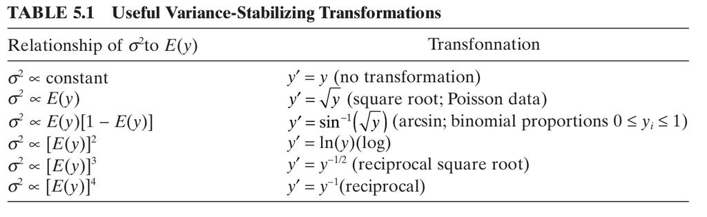

# Variance-Stabilizing Transformations

Example:

$Y \sim \text{Poisson}\left(\lambda_x\right)$, then $E[Y] = V[Y] = \lambda_x$ (violation of linear model assumptions!)

Solution: run a regression using $\tilde{Y} = \sqrt{Y}$
$$V[\sqrt{Y}] \approx \left\{\frac{1}{2} E[Y]^{-1/2}\right\}^2 E[Y] = \frac{1}{4}$$

now the variance doesn’t depend on the mean!

# Variance-Stabilizing Transformations

Why though?

It’s because of something called the *Delta Method*, which is a way to approximate first and second moments of transformed random variables.

If $W$ has $E[W]$ and $V[W]$, and $g$ is some transformation, under certain regularlity conditions

$$V[g(W)] \approx \{g'(E[W])\}^2 V[W]$$

# Example

You just ran a regression, and go to check your residuals, and you see this:

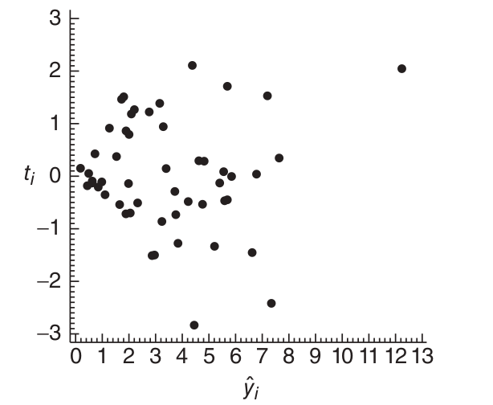

peak-hour energy demand (y) versus total monthly energy usage (x)

# Example (continued)

After a square root transformation

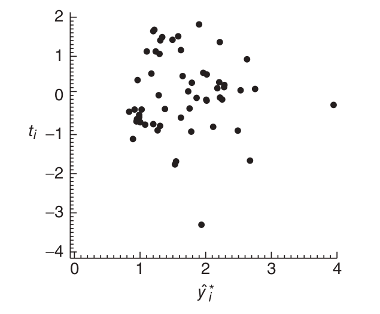

# The Box-Cox procedure

Q: how do I choose a power on my own for the response variable $y^{\lambda}$?

A: Make it a parameter of the model!

Maybe this:

$$y^{\lambda} = \mathbf{x}_i^{\intercal}\boldsymbol{\beta} + \epsilon$$

# The Box-Cox procedure

Q: what do we do about really small values of $\lambda$ for $y^{\lambda}$?

Maybe this?
$$\frac{y^{\lambda}}{\lambda} = \mathbf{x}_i^{\intercal}\boldsymbol{\beta} + \epsilon$$

# The Box-Cox procedure

Or maybe this:
$$\frac{y^{\lambda}-1}{\lambda} = \mathbf{x}_i^{\intercal}\boldsymbol{\beta} + \epsilon$$

Notice that
$$\lim_{\lambda \to 0}\frac{y^{\lambda}-1}{\lambda} = \lim_{\lambda \to 0}\frac{\exp[\lambda \log y]-1}{\lambda} = \lim_{\lambda \to 0}\exp[\lambda \log y] \log y = \log y < \infty$$

[figure not shown]

Guillaume de l’Hôpital (source: wikipedia)

# The Box-Cox procedure

So we’ll go with this:

$$\frac{y^{\lambda}-1}{\lambda} = \beta_0 + x_1\beta_1 + \cdots x_k\beta_k + \epsilon$$

Confusion arises because there is a difference between
$$f\left(\frac{y_1^{\lambda}-1}{\lambda}, \ldots, \frac{y_n^{\lambda}-1}{\lambda} \bigg\rvert \lambda, \boldsymbol{\beta}, \sigma^2\right)$$
and

$$f\left(y_1, \ldots, y_n \mid \lambda, \boldsymbol{\beta}, \sigma^2\right)$$

We maximize the second one!

# The Box-Cox procedure

We have to solve these

$$\frac{\partial \log f(y_1, \ldots, y_n \mid \lambda, \boldsymbol{\beta}, \sigma^2)}{\partial \boldsymbol{\beta}} \overset{\text{set}}{=} \mathbf{0}$$
$$\frac{\partial \log f(y_1, \ldots, y_n \mid \lambda, \boldsymbol{\beta}, \sigma^2)}{\partial \sigma^2} \overset{\text{set}}{=} 0$$

$$\frac{\partial \log f(y_1, \ldots, y_n \mid \lambda, \boldsymbol{\beta}, \sigma^2)}{\partial \lambda} \overset{\text{set}}{=} 0$$

Solving the first two and then plugging them in gives the *profile log-likelihood* $\ell(\lambda)$. That’s maximized last.

# The Box-Cox procedure

The *profile log-likelihood* is easy to get in `R`

```r
library(MASS)
bc_res <- boxcox(y ~ ., data = my_data) # looks like lm()
```

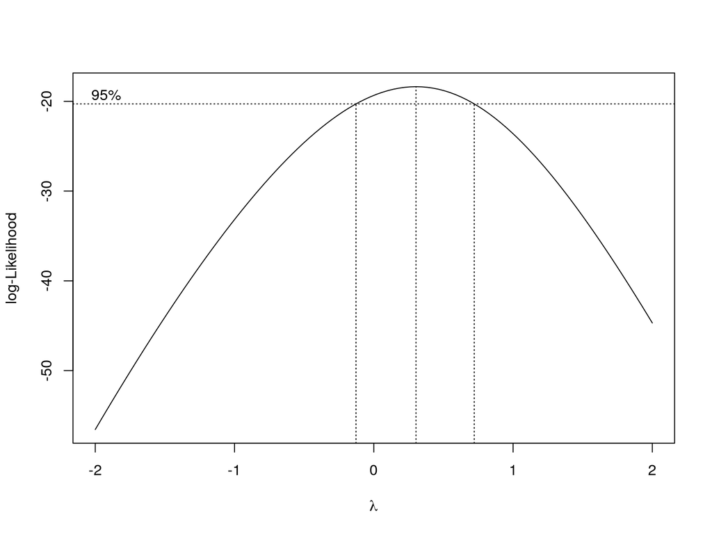

# The Box-Cox procedure

```r
best_lambda <- bc_res$x[bc_res$y == max(bc_res$y)] # or manually choose one in the range
cat(best_lambda)
```

```
## 0.3030303
```

```r
my_data$transformed_y <- (my_data$y^best_lambda - 1)/best_lambda
head(my_data)
```

```
##       y   x1  x2    x3    x4      x5      x6   x7 transformed_y
## 1 36.98  5.1 400 51.37  4.24 1484.83 2227.25 2.06      6.554973
## 2 13.74 26.4 400 72.33 30.87  289.94  434.90 1.33      4.000597
## 3 10.08 23.8 400 71.44 33.01  320.79  481.19 0.97      3.346498
## 4  8.53 46.4 400 79.15 44.61  164.76  247.14 0.62      3.018583
## 5 36.42  7.0 450 80.47 33.84 1097.26 1645.89 0.22      6.509509
## 6 26.59 12.6 450 89.90 41.26  605.06  907.59 0.76      5.617575
```

```r
final_mod <- lm(transformed_y ~ . - y, data = my_data)  # the minus sign means "except for"
```

# Linearization

Alternatively, the “true” model can be written as a linear model.

If a “subject-matter expert” tells you that the model is

$$y = \beta_0 e^{\beta_1 x}\epsilon$$
then
$$\log y = \log \beta_0 + \beta_1 x + \log \epsilon$$

- assume $\epsilon$ is log-normally distributed
- transform $y \mapsto \log y = \tilde{y}$
- regress on original $x$
- be careful of parameter interpretations

# Linearization

Another example

$$y = \beta_0 + \beta_1 \frac{1}{x} + \epsilon$$

is
$$y = \beta_0 + \beta_1 \tilde{x} + \epsilon$$

where $\frac{1}{x} = \tilde{x}$

more examples on page 178